# Group 20

- Plotting residuals vs. fitted values

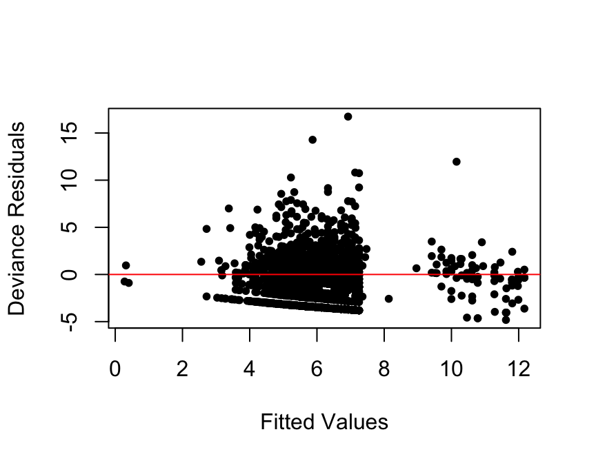

  Figure 2: Residuals vs. Fitted Values Plot for Poissron Regression Model

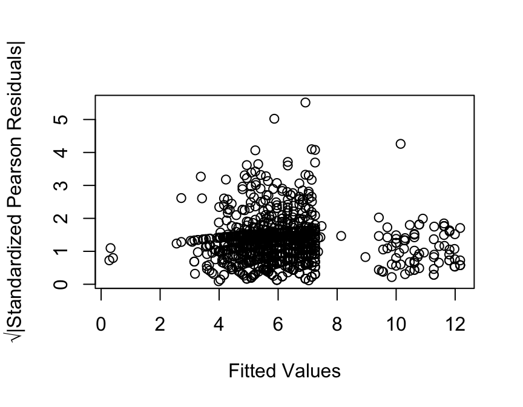

  Figure 3: Scale-Location Plot (Spread vs. Level Plot)

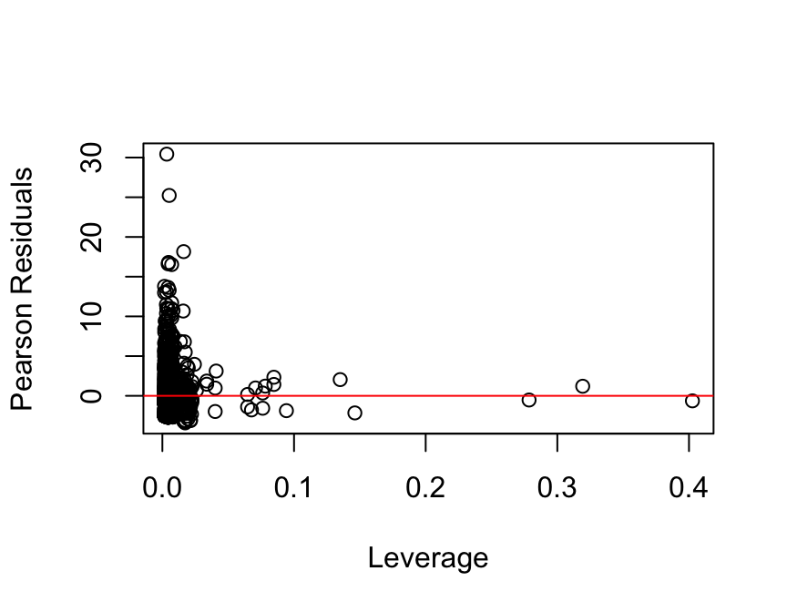

  Figure 4: Residuals vs. Leverage Plot

When diagnostic plots provide different insights, it is crucial to consider the overall evidence and the specific research context. If overdispersion is a consistent concern across multiple diagnostics (like the Residuals vs. Fitted Values Plot and the Scale-Location Plot), it often outweighs indications from other plots that the model might be adequate for most data points. Therefore, even if the Residuals vs. Leverage Plot suggests the model is mostly fitting well, the evidence of overdispersion from the other plots is a strong indicator that the Poisson model might not be the best choice. Exploring alternative models like the Negative Binomial, which can accommodate overdispersion, is likely a prudent step to improve model fit and ensure more reliable inference from the model.

### Negative Binomial Model

It will be conducted the Negative Binomial Model which is a good alternative model when the assumption of equidispersion (mean equals variance) in Poisson regression doesn’t hold.

```
Call:
glm.nb(formula = time_at_shelter ~ animal_type + month + year +
    intake_type + chip_status, data = data, init.theta = 0.7625369942,
    link = log)

Coefficients:
                            Estimate Std. Error z value Pr(>|z|)
(Intercept)                620.40667  232.62169   2.667  0.00765 **
animal_typeCAT               2.76946    1.19772   2.312  0.02076 *
animal_typeDOG               2.86336    1.19617   2.394  0.01668 *
animal_typeWILDLIFE          2.58130    1.24807   2.068  0.03862 *
month                       -0.03283    0.01507  -2.178  0.02938 *
year                        -0.30775    0.11532  -2.669  0.00761 **
intake_typeOWNER SURRENDER  -0.75490    0.14319  -5.272 1.35e-07 ***
intake_typeSTRAY            -0.55483    0.13728  -4.042 5.31e-05 ***
chip_statusSCAN NO CHIP      0.01468    0.08355   0.176  0.86054
chip_statusUNABLE TO SCAN   -0.47382    0.18025  -2.629  0.00857 **
---
Signif. codes:  0 '***' 0.001 '**' 0.01 '*' 0.05 '.' 0.1 ' ' 1

(Dispersion parameter for Negative Binomial(0.7625) family taken to be 1)

    Null deviance: 1743.0  on 1464  degrees of freedom
Residual deviance: 1687.1  on 1455  degrees of freedom
AIC: 8352.4

Number of Fisher Scoring iterations: 1

              Theta:  0.7625
          Std. Err.:  0.0348

 2 x log-likelihood:  -8330.4070
```

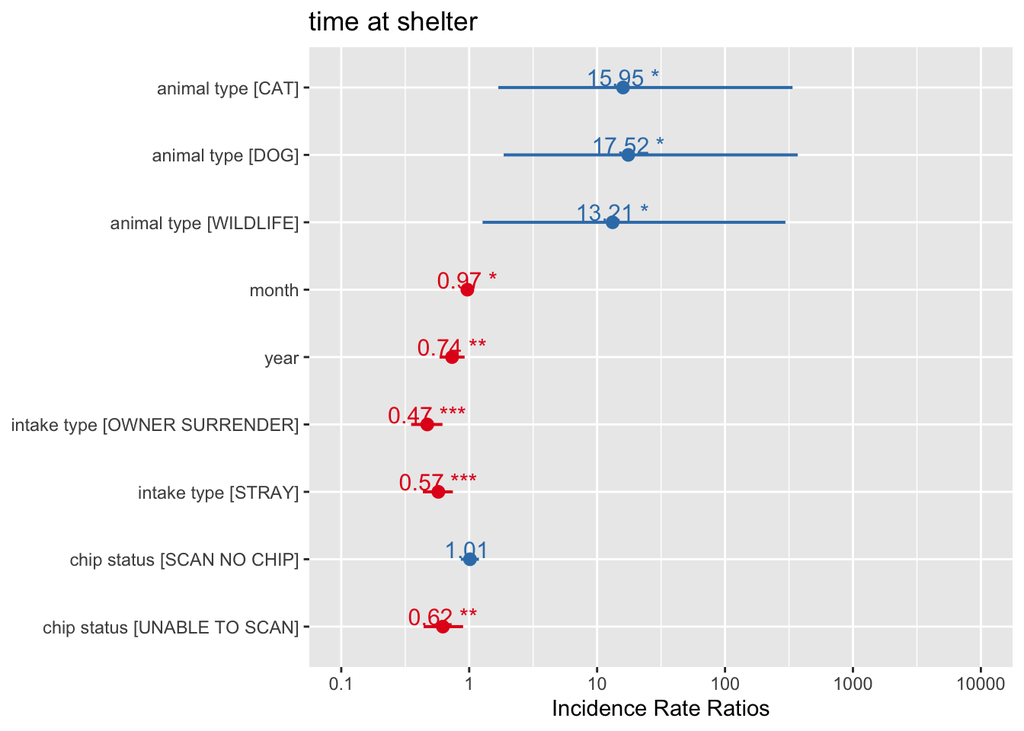

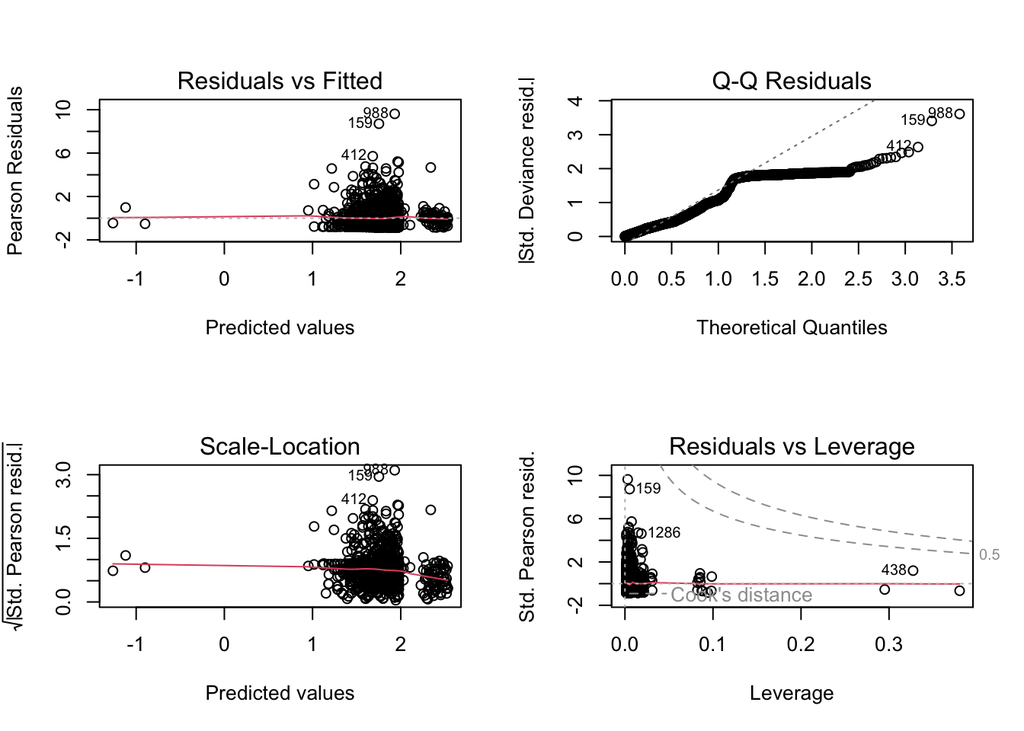

```
[1] 14316.41
```

```
[1] 8352.407
```

```
Single term deletions

Model:
time_at_shelter ~ animal_type + month + year + intake_type +
    chip_status
            Df Deviance    AIC F value    Pr(>F)
<none>           1687.1 8350.4
animal_type  3   1694.8 8352.1  2.2228   0.08373 .
month        1   1691.8 8353.1  4.0458   0.04446 *
year         1   1694.3 8355.6  6.1796   0.01303 *
intake_type  2   1718.9 8378.2 13.7054 1.268e-06 ***
chip_status  2   1694.8 8354.1  3.3072   0.03689 *
---
Signif. codes:  0 '***' 0.001 '**' 0.01 '*' 0.05 '.' 0.1 ' ' 1
```

## Model Interpretation and Conclusion